# Project Python Foundations: FoodHub Data Analysis

**Marks: 60**

```python
!pip install nbconvert
```

```python
!jupyter nbconvert --to html Final_Project_NS.ipynb
```

```
[NbConvertApp] Converting notebook Final_Project_NS.ipynb to html
[NbConvertApp] Writing 2778625 bytes to Final_Project_NS.html
```

### Context

The number of restaurants in New York is increasing day by day. Lots of students and busy professionals rely on those restaurants due to their hectic lifestyles. Online food delivery service is a great option for them. It provides them with good food from their favorite restaurants. A food aggregator company FoodHub offers access to multiple restaurants through a single smartphone app.

The app allows the restaurants to receive a direct online order from a customer. The app assigns a delivery person from the company to pick up the order after it is confirmed by the restaurant. The delivery person then uses the map to reach the restaurant and waits for the food package. Once the food package is handed over to the delivery person, he/she confirms the pick-up in the app and travels to the customer's location to deliver the food. The delivery person confirms the drop-off in the app after delivering the food package to the customer. The customer can rate the order in the app. The food aggregator earns money by collecting a fixed margin of the delivery order from the restaurants.

### Objective

The food aggregator company has stored the data of the different orders made by the registered customers in their online portal. They want to analyze the data to get a fair idea about the demand of different restaurants which will help them in enhancing their customer experience. Suppose you are hired as a Data Scientist in this company and the Data Science team has shared some of the key questions that need to be answered. Perform the data analysis to find answers to these questions that will help the company to improve the business.

### Data Description

The data contains the different data related to a food order. The detailed data dictionary is given below.

### Data Dictionary

- order_id: Unique ID of the order
- customer_id: ID of the customer who ordered the food
- restaurant_name: Name of the restaurant
- cuisine_type: Cuisine ordered by the customer
- cost: Cost of the order
- day_of_the_week: Indicates whether the order is placed on a weekday or weekend (The weekday is from Monday to Friday and the weekend is Saturday and Sunday)
- rating: Rating given by the customer out of 5
- food_preparation_time: Time (in minutes) taken by the restaurant to prepare the food. This is calculated by taking the difference between the timestamps of the restaurant's order confirmation and the delivery person's pick-up confirmation.
- delivery_time: Time (in minutes) taken by the delivery person to deliver the food package. This is calculated by taking the difference between the timestamps of the delivery person's pick-up confirmation and drop-off information

### Let us start by importing the required libraries

```python
# import libraries for data manipulation
import numpy as np
import pandas as pd

# import libraries for data visualization
import matplotlib.pyplot as plt
import seaborn as sns
# to restrict the float value to 3 decimal places
pd.set_option('display.float_format', lambda x: '%.3f' % x)
```

### Understanding the structure of the data

```python
# uncomment and run the following lines for Google Colab
from google.colab import drive
drive.mount('/content/drive')
```

```python
path=('/content/drive/MyDrive/Great Learning /Project 1 - FoodHub Data Analysis/foodhub_order.csv')
```

```python
# read the data
df = pd.read_csv(path)
# returns the first 5 rows
df.head()
```

|  | order_id | customer_id | restaurant_name | cuisine_type | cost_of_the_order | day_of_the_week | rating | food_preparation_time | delivery_time |
| --- | --- | --- | --- | --- | --- | --- | --- | --- | --- |
| 0 | 1477147 | 337525 | Hangawi | Korean | 30.750 | Weekend | Not given | 25 | 20 |
| 1 | 1477685 | 358141 | Blue Ribbon Sushi Izakaya | Japanese | 12.080 | Weekend | Not given | 25 | 23 |
| 2 | 1477070 | 66393 | Cafe Habana | Mexican | 12.230 | Weekday | 5 | 23 | 28 |
| 3 | 1477334 | 106968 | Blue Ribbon Fried Chicken | American | 29.200 | Weekend | 3 | 25 | 15 |
| 4 | 1478249 | 76942 | Dirty Bird to Go | American | 11.590 | Weekday | 4 | 25 | 24 |

```python
df.tail()
```

|  | order_id | customer_id | restaurant_name | cuisine_type | cost_of_the_order | day_of_the_week | rating | food_preparation_time | delivery_time |
| --- | --- | --- | --- | --- | --- | --- | --- | --- | --- |
| 1893 | 1476701 | 292602 | Chipotle Mexican Grill $1.99 Delivery | Mexican | 22.310 | Weekend | 5 | 31 | 17 |
| 1894 | 1477421 | 397537 | The Smile | American | 12.180 | Weekend | 5 | 31 | 19 |
| 1895 | 1477819 | 35309 | Blue Ribbon Sushi | Japanese | 25.220 | Weekday | Not given | 31 | 24 |
| 1896 | 1477513 | 64151 | Jack's Wife Freda | Mediterranean | 12.180 | Weekday | 5 | 23 | 31 |
| 1897 | 1478056 | 120353 | Blue Ribbon Sushi | Japanese | 19.450 | Weekend | Not given | 28 | 24 |

#### Observations:

- *The DataFrame has 9 columns as mentioned in the Data Dictionary. Data in each row corresponds to the order placed by a customer*
- *The column of day of the week consists weekday and weekends which is ordered by customers*
- *The performance of each Restaurant has been defined by the users under rating column*
- *Dataset also represents food preparation time and delivery time columns captured on the system*
- *From the head and tail of the dataset, it can be observed that there are some values as Not given, which means the dataset might have some missing values*

### **Question 1:** How many rows and columns are present in the data? [0.5 mark]

```python
# Write your code here
# checking shape of the data
print("There are", df.shape[0], 'rows and', df.shape[1], "columns.")
```

```
There are 1898 rows and 9 columns.
```

#### Observations:

- *The Dataset has 1898 number of rows with 9 columns*

### **Question 2:** What are the datatypes of the different columns in the dataset? (The info() function can be used) [0.5 mark]

```python
# Use info() to print a concise summary of the DataFrame
df.info()
```

```
<class 'pandas.core.frame.DataFrame'>
RangeIndex: 1898 entries, 0 to 1897
Data columns (total 9 columns):
 #   Column                 Non-Null Count  Dtype
---  ------                 --------------  -----
 0   order_id               1898 non-null   int64
 1   customer_id            1898 non-null   int64
 2   restaurant_name        1898 non-null   object
 3   cuisine_type           1898 non-null   object
 4   cost_of_the_order      1898 non-null   float64
 5   day_of_the_week        1898 non-null   object
 6   rating                 1898 non-null   object
 7   food_preparation_time  1898 non-null   int64
 8   delivery_time          1898 non-null   int64
dtypes: float64(1), int64(4), object(4)
memory usage: 133.6+ KB
```

#### Observations:

- *We can observe that there around 4 object datatype columns and 5 numerical datatype*
- *Rating column is being read as object type column but it should be in numerical column*
- *All the columns have 1898 observations which means no missing values and can be inferred that there are no null values present in the dataset. However as we have mixed datatype on rating column it may lead us to missing value treatment actions*

### **Question 3:** Are there any missing values in the data? If yes, treat them using an appropriate method. [1 mark]

```python
# Write your code here
df.isnull().sum()
```

```
order_id                 0
customer_id              0
restaurant_name          0
cuisine_type             0
cost_of_the_order        0
day_of_the_week          0
rating                   0
food_preparation_time    0
delivery_time            0
dtype: int64
```

```python
df.isnull().sum().sum()
```

```
0
```

```python
# checking the count of different data types in rating column
df['rating'].apply(type).value_counts()
```

```
<class 'str'>    1898
Name: rating, dtype: int64
```

#### Observations:

- *The Dataset shows that there is no any missing values present. However we can see on head and tail dataset in the column rating 'Not given' which should actually read as missing values or as (NaN)*
- *We need to replace such data points with null values*

```python
# changing the data type of rating column
# replacing values with nan
df['rating'] = df['rating'].replace(['Not given'],np.nan)
```

```python
df['rating'].unique()
```

```
array([nan, '5', '3', '4'], dtype=object)
```

```python
# checking the count of different data types in rating column
df['rating'].apply(type).value_counts()
```

```
<class 'str'>      1162
<class 'float'>     736
Name: rating, dtype: int64
```

```python
# changing the data type to float
df['rating'] = df['rating'].astype(float)
```

```python
# checking the datatype if it has been fixed
df.info()
```

```
<class 'pandas.core.frame.DataFrame'>
RangeIndex: 1898 entries, 0 to 1897
Data columns (total 9 columns):
 #   Column                 Non-Null Count  Dtype
---  ------                 --------------  -----
 0   order_id               1898 non-null   int64
 1   customer_id            1898 non-null   int64
 2   restaurant_name        1898 non-null   object
 3   cuisine_type           1898 non-null   object
 4   cost_of_the_order      1898 non-null   float64
 5   day_of_the_week        1898 non-null   object
 6   rating                 1162 non-null   float64
 7   food_preparation_time  1898 non-null   int64
 8   delivery_time          1898 non-null   int64
dtypes: float64(2), int64(4), object(3)
memory usage: 133.6+ KB
```

Observations:

- *We can see that the data types of rating has been Fixed*
- *There are 6 numerical columns and 3 object data type in the dataset*
- *We observe that rating column has 1162 entries that is less than 1898 which indicates the presence of missing values in the data*

```python
# checking the missing values present in the data
df.isnull().sum()
```

```
order_id                   0
customer_id                0
restaurant_name            0
cuisine_type               0
cost_of_the_order          0
day_of_the_week            0
rating                   736
food_preparation_time      0
delivery_time              0
dtype: int64
```

```python
df.isnull().sum().sum()
```

```
736
```

```python
# data.shape[0] will give us the number of rows in the dataset
# selecting the instances where missing value is greater than 0
pd.DataFrame({'Count':df.isnull().sum()[df.isnull().sum()>0],'Percentage':(df.isnull().sum()[df.isnull().sum()>0]/df.shape[0])*100})
```

|  | Count | Percentage |
| --- | --- | --- |
| rating | 736 | 38.778 |

Comment:

- *As we have a high percentage of missing values (38% in our case) and the column may contain outliers, using the mean method for imputing missing values is appropriate. The mean provides a measure of central, tendency that considers all available values in the column, including non-missing values*
- *Although the mean can be influenced by outliers, it still provides a reasonable estimation in most cases. By replacing missing values with the mean, we can preserve the overall distribution of the data. This approach will also provide a more reliable estimation of the missing values while minimizing the impact of outliers on the imputations*

```python
df['rating'] = df['rating'].fillna(value= df['rating'].mean())
```

```python
df.isnull().sum()
```

```
order_id                 0
customer_id              0
restaurant_name          0
cuisine_type             0
cost_of_the_order        0
day_of_the_week          0
rating                   0
food_preparation_time    0
delivery_time            0
dtype: int64
```

Comment:

- *All the missing values have been imputed and there are no missing values in our dataset now*

### **Question 4:** Check the statistical summary of the data. What is the minimum, average, and maximum time it takes for food to be prepared once an order is placed? [2 marks]

```python
# Write your code here
df.describe(include= 'all').T
```

|  | count | unique | top | freq | mean | std | min | 25% | 50% | 75% | max |
| --- | --- | --- | --- | --- | --- | --- | --- | --- | --- | --- | --- |
| order_id | 1898.000 | NaN | NaN | NaN | 1477495.500 | 548.050 | 1476547.000 | 1477021.250 | 1477495.500 | 1477969.750 | 1478444.000 |
| customer_id | 1898.000 | NaN | NaN | NaN | 171168.478 | 113698.140 | 1311.000 | 77787.750 | 128600.000 | 270525.000 | 405334.000 |
| restaurant_name | 1898 | 178 | Shake Shack | 219 | NaN | NaN | NaN | NaN | NaN | NaN | NaN |
| cuisine_type | 1898 | 14 | American | 584 | NaN | NaN | NaN | NaN | NaN | NaN | NaN |
| cost_of_the_order | 1898.000 | NaN | NaN | NaN | 16.499 | 7.484 | 4.470 | 12.080 | 14.140 | 22.297 | 35.410 |
| day_of_the_week | 1898 | 2 | Weekend | 1351 | NaN | NaN | NaN | NaN | NaN | NaN | NaN |
| rating | 1898.000 | NaN | NaN | NaN | 4.344 | 0.580 | 3.000 | 4.000 | 4.344 | 5.000 | 5.000 |
| food_preparation_time | 1898.000 | NaN | NaN | NaN | 27.372 | 4.632 | 20.000 | 23.000 | 27.000 | 31.000 | 35.000 |
| delivery_time | 1898.000 | NaN | NaN | NaN | 24.162 | 4.973 | 15.000 | 20.000 | 25.000 | 28.000 | 33.000 |

### **Question 5:** How many orders are not rated? [1 mark]

```python
# Write the code here
nan_counts = df['rating'].value_counts(dropna=False)
# Displaying the counts
print(nan_counts)
```

```
4.344    736
5.000    588
4.000    386
3.000    188
Name: rating, dtype: int64
```

### Exploratory Data Analysis (EDA)

### **Question 6:** Explore all the variables and provide observations on their distributions. (Generally, histograms, boxplots, countplots, etc. are used for univariate exploration.) [9 marks]

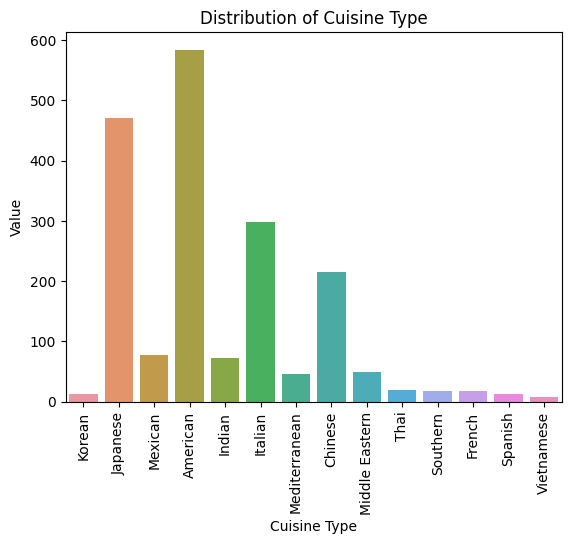

```python
sns.countplot(data=df,x='cuisine_type')
plt.xticks(rotation=90)
plt.xlabel('Cuisine Type')
plt.ylabel('Value')
plt.title('Distribution of Cuisine Type')
plt.show()
```

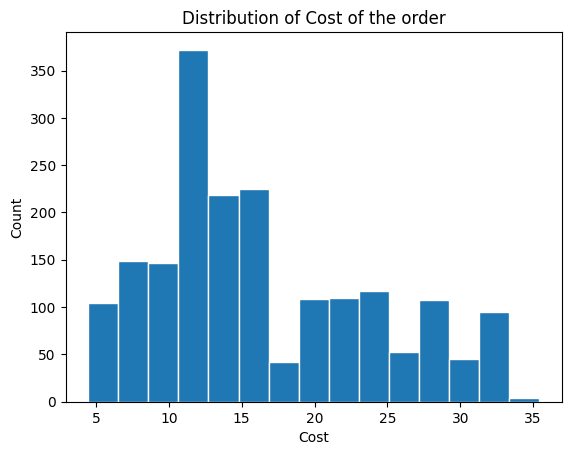

```python
cost_data = df['cost_of_the_order']
plt.hist(cost_data, bins=15, edgecolor='white')
plt.xlabel('Cost')
plt.ylabel('Count')
plt.title('Distribution of Cost of the order')
plt.show()
```

- *The histogram appears to be slightly skewed to the right, suggesting a possible right-skewness*
- *This indicates that there might be a higher frequency of lower cost orders and exhibits some skewness towards lower cost values*

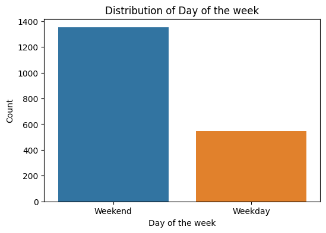

```python
plt.figure(figsize=(6,4))
sns.countplot(data=df, x='day_of_the_week');
plt.title('Distribution of Day of the week')
plt.xlabel('Day of the week')
plt.ylabel('Count')
plt.show()
```

- *The countplot illustrates the distribution of orders across weekdays and weekends*
- *It is evident that the restaurants receive a higher number of orders on weekends compared to weekdays*
- *This indicates that customers prefer to place orders more frequently on weekends, resulting in a noticeable increase in orders during that time*

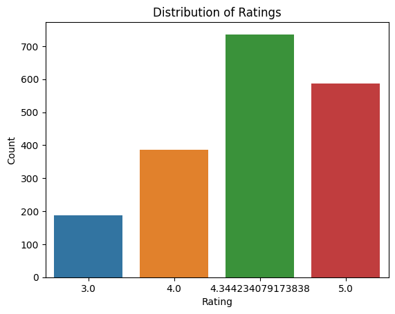

```python
sns.countplot(data=df, x='rating')

plt.title('Distribution of Ratings')
plt.xlabel('Rating')
plt.ylabel('Count')

plt.show()
```

- *It is highlighted that the countplot displays the distribution of ratings received by the restaurants*
- *Four main rating categories and notes that the highest count is for a rating of 4.3, closely followed by 5.0*

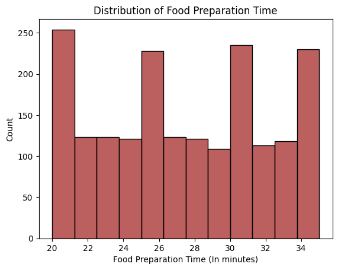

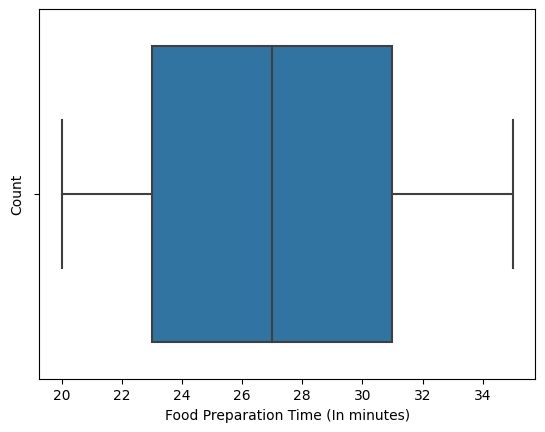

```python
sns.histplot(data=df,x='food_preparation_time',color='brown')
plt.xlabel('Food Preparation Time (In minutes)')
plt.ylabel('Count')
plt.title('Distribution of Food Preparation Time')
plt.show()
sns.boxplot(data=df,x='food_preparation_time')
plt.xlabel('Food Preparation Time (In minutes)')
plt.ylabel('Count')
plt.show()
```

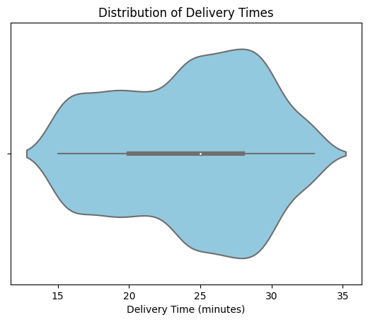

```python
sns.violinplot(data=df, x='delivery_time',color='skyblue')

plt.title('Distribution of Delivery Times')
plt.xlabel('Delivery Time (minutes)')

plt.show()
```

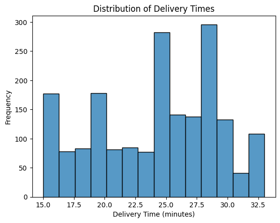

```python
sns.histplot(data=df, x='delivery_time', bins='auto')

plt.title('Distribution of Delivery Times')
plt.xlabel('Delivery Time (minutes)')
plt.ylabel('Frequency')

plt.show()
```

- *As we can see that the interquartile range (IQR) represents between 20 min and 28 min and median range about less than 25 min. Some delivery times make take longer subject to the location and other factors*

### **Question 7**: Which are the top 5 restaurants in terms of the number of orders received? [1 mark]

```python
# Write the code here
top_restaurants = df['restaurant_name'].value_counts().head(5)

print("Top 5 restaurants by order count:")
print(top_restaurants)
```

```
Top 5 restaurants by order count:
Shake Shack                  219
The Meatball Shop            132
Blue Ribbon Sushi            119
Blue Ribbon Fried Chicken     96
Parm                          68
Name: restaurant_name, dtype: int64
```

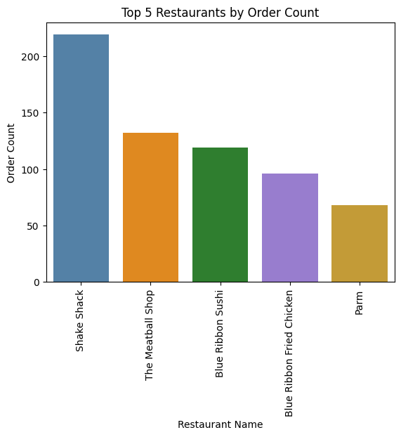

```python
# Get the top 5 restaurants by order count
top_restaurants = df['restaurant_name'].value_counts().head(5)

# Creating a bar chart to visualize the top restaurants
plt.bar(top_restaurants.index, top_restaurants.values)
colors = ['steelblue', 'darkorange', 'forestgreen', 'mediumpurple', 'goldenrod']
# Creating a bar plot with different colors for each bar
sns.barplot(x=top_restaurants.index, y=top_restaurants.values, palette=colors)
plt.xlabel('Restaurant Name')
plt.ylabel('Order Count')
plt.title('Top 5 Restaurants by Order Count')
plt.xticks(rotation=90)
plt.show()
```

#### Observations:

- *This information provides valuable insights into the popularity and demand for these restaurants based on the number of orders they have received*
- *The restaurant "Shake Shack" has the highest order count with 219 orders, followed by "The Meatball Shop" with 132 orders, "Blue Ribbon Sushi" with 119 orders, "Blue Ribbon Fried Chicken" with 96 orders, and "Parm" with 68 orders*

### **Question 8**: Which is the most popular cuisine on weekends? [1 mark]

```python
# Write the code here
# Filtering the DataFrame to include only orders placed on weekends
weekend_orders = df[df['day_of_the_week'].isin(['Weekend'])]

# Counting the number of orders for each cuisine type
most_popular_cuisine = weekend_orders['cuisine_type'].value_counts().head(10)

print("Most popular cuisine on weekends by order count:")
print(most_popular_cuisine)
```

```
Most popular cuisine on weekends by order count:
American          415
Japanese          335
Italian           207
Chinese           163
Mexican            53
Indian             49
Mediterranean      32
Middle Eastern     32
Thai               15
French             13
Name: cuisine_type, dtype: int64
```

#### Observations:

- *As we can see the most popular cuisine on weekends is "American" with 415 orders, followed by "Japanese","Italian","Chinese" and "Mexican" cuisines*
- *This information provides insights into the preferred cuisines during weekends and highlights the popularity of certain cuisine types among customers*

### **Question 9**: What percentage of the orders cost more than 20 dollars? [2 marks]

```python
# Write the code here
cost_above_20 = df[df['cost_of_the_order'] > 20]

# Calculating the percentage of orders with cost > $20
percentage = round((cost_above_20.shape[0] / df.shape[0]) * 100, 2)

print(f"The percentage of orders that cost more than $20 is: {percentage}%")
```

```
The percentage of orders that cost more than $20 is: 29.24%
```

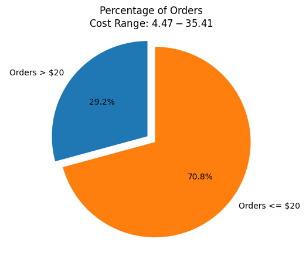

```python
# Calculating the percentage of orders with cost > $20
percentage = round((cost_above_20.shape[0] / df.shape[0]) * 100, 2)
# Calculating the range of cost of orders
cost_range = f"${df['cost_of_the_order'].min()} - ${df['cost_of_the_order'].max()}"
# Creating the pie chart
labels = ['Orders > $20', 'Orders <= $20']
sizes = [percentage, 100 - percentage]
explode = (0.1, 0)
plt.pie(sizes, explode=explode, labels=labels, autopct='%1.1f%%', startangle=90)
plt.title('Percentage of Orders\nCost Range: ' + cost_range)
plt.axis('equal')
plt.show()
```

#### Observations:

- *Around 29% of orders (more than one quarter) cost more than 20 USD*
- *Cost ranges between 4.47 and 35.41*

### **Question 10**: What is the mean order delivery time? [1 mark]

```python
# Write the code here
mean_delivery_time = df['delivery_time'].mean()
# Rounding the mean delivery time to 2 decimal places
mean_delivery_time = round(mean_delivery_time, 2)
print(f"The mean order delivery time: {mean_delivery_time}")
```

```
The mean order delivery time: 24.16
```

### **Question 11:** The company has decided to give 20% discount vouchers to the top 3 most frequent customers. Find the IDs of these customers and the number of orders they placed. [1 mark]

```python
# Write the code here
# Counting the number of orders placed by each customer
customer_order_counts = df['customer_id'].value_counts()

# Getting the top 3 customers with the highest order counts
top_customers = customer_order_counts.head(3)

# Extracting the customer IDs and order counts
top_customer_ids = top_customers.index
top_customer_order_counts = top_customers.values

print("Top 3 most frequent customers:")
for customer_id, order_count in zip(top_customer_ids, top_customer_order_counts):
    print(f"Customer ID: {customer_id}, Number of Orders: {order_count}")
```

```
Top 3 most frequent customers:
Customer ID: 52832, Number of Orders: 13
Customer ID: 47440, Number of Orders: 10
Customer ID: 83287, Number of Orders: 9
```

#### Observations:

- *Those customers stand out as the most frequent and valuable customers, contributing significantly to the company's order volume and potentially representing a strong customer base for the business, also providing a clear benefit for the loyal customers can motivate them*

### **Question 12**: Perform a multivariate analysis to explore relationships between the important variables in the dataset. (It is a good idea to explore relations between numerical variables as well as relations between numerical and categorical variables) [10 marks]

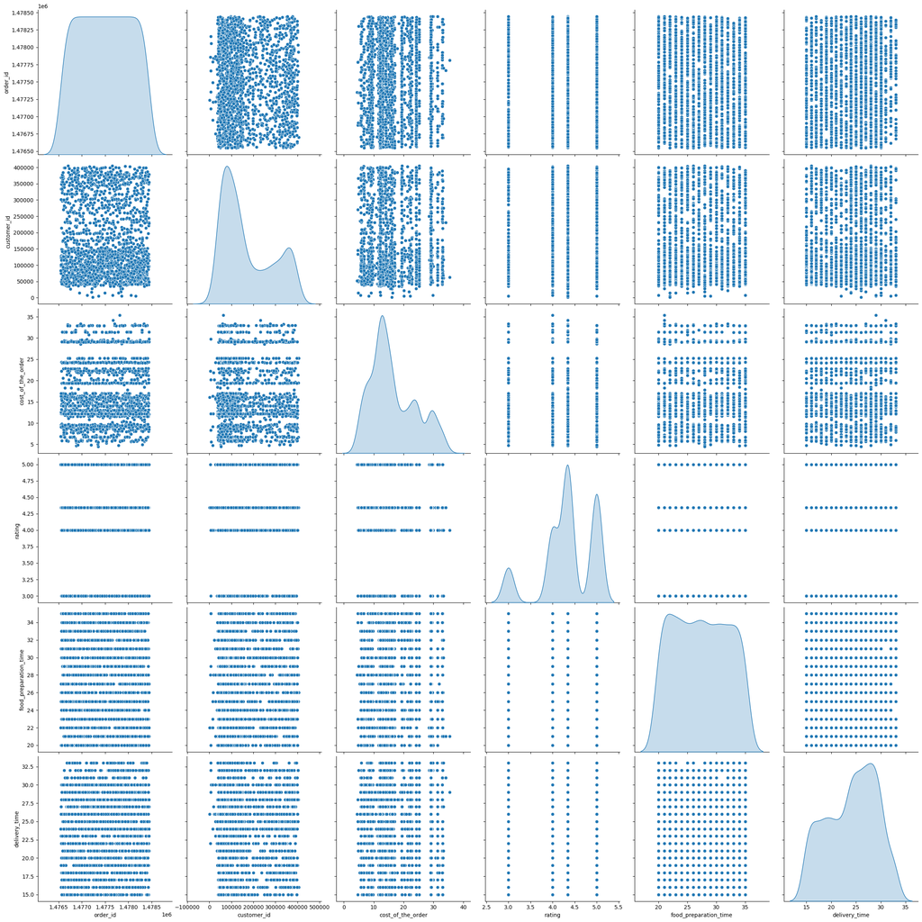

```python
sns.pairplot(data=df, diag_kind="kde", height=4)
plt.show();
```

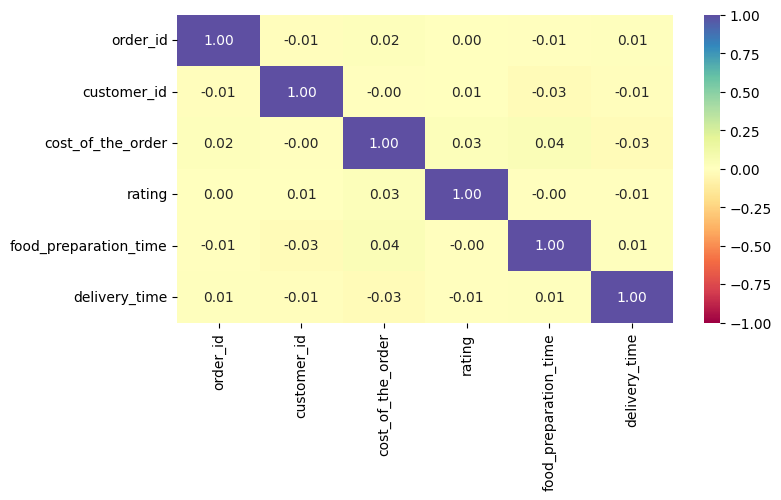

```python
corr = df.corr(numeric_only=True)
# Plot the heatmap
plt.figure(figsize=(8, 4))
sns.heatmap(corr, annot=True, vmin=-1, vmax=1, fmt=".2f", cmap="Spectral")
plt.show()
```

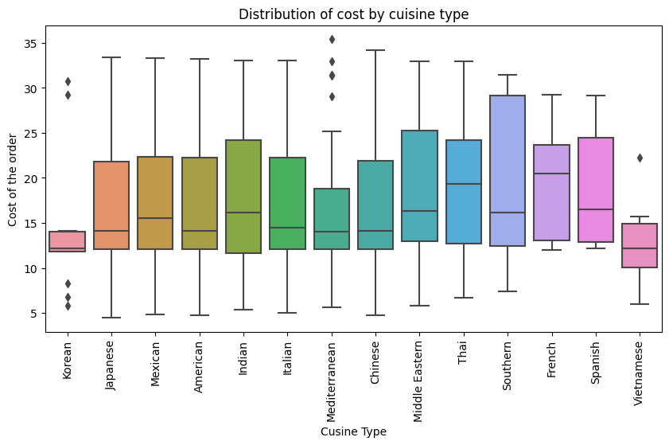

```python
plt.figure(figsize=(10,5))
sns.boxplot(data=df, x='cuisine_type', y='cost_of_the_order')
plt.xlabel('Cusine Type')
plt.ylabel('Cost of the order')
plt.title('Distribution of cost by cuisine type')
plt.xticks(rotation=90);
```

- *As it can be observed that median cost of the order is above 10 with some outlier in Korean, Mediterranean and Vietnamese cusine*

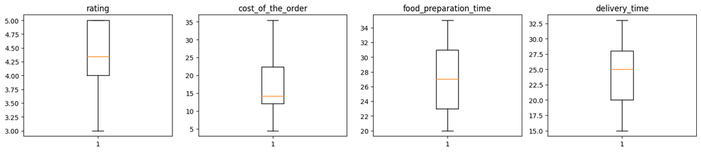

```python
# outlier detection using boxplot
# selecting the numerical columns of data and adding their names in a list
numeric_columns = ['rating', 'cost_of_the_order', 'food_preparation_time', 'delivery_time']
plt.figure(figsize=(15, 12))

for i, variable in enumerate(numeric_columns):
    plt.subplot(4, 4, i + 1)
    plt.boxplot(df[variable], whis=1.5)
    plt.tight_layout()
    plt.title(variable)

plt.show()
```

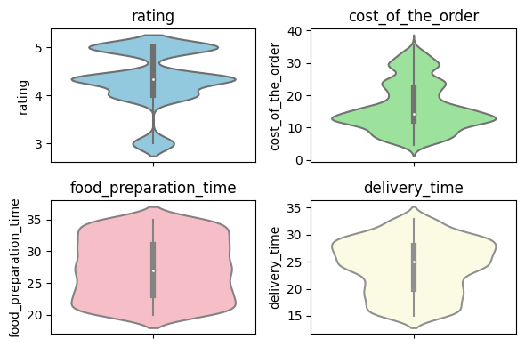

```python
# Outlier detection using violin plots
# Selecting the numerical columns of data and adding their names in a list
numeric_columns = ['rating', 'cost_of_the_order', 'food_preparation_time', 'delivery_time']
plt.figure(figsize=(6, 4))
colors = ['skyblue', 'lightgreen', 'lightpink', 'lightyellow']

for i, variable in enumerate(numeric_columns):
    plt.subplot(2, 2, i + 1)
    sns.violinplot(data=df, y=variable, color=colors[i])
    plt.title(variable)
    plt.tight_layout()

plt.show()
```

- *As we can see from the above different visualisations, there is absence of significant outliers, it indicates that the data points in those columns are within a reasonable range and do not require special treatment or handling*
- *This suggests that the data is relatively consistent and does not contain extreme values that could potentially skew the analysis or affect the interpretation of the results*

### **Question 13:** The company wants to provide a promotional offer in the advertisement of the restaurants. The condition to get the offer is that the restaurants must have a rating count of more than 50 and the average rating should be greater than 4. Find the restaurants fulfilling the criteria to get the promotional offer. [3 marks]

```python
# Write the code here
# Group the data by restaurant and calculate the rating count and average rating
restaurant_data = df.groupby('restaurant_name').agg({'rating': ['count', 'mean']})

# Filter the restaurants fulfilling the criteria
promotional_restaurants = restaurant_data[(restaurant_data['rating']['count'] > 50) & (restaurant_data['rating']['mean'] > 4)]

# Print the restaurants fulfilling the criteria
print("Restaurants fulfilling the criteria for the promotional offer:")
print(promotional_restaurants)
```

```
Restaurants fulfilling the criteria for the promotional offer:
                          rating
                           count  mean
restaurant_name
Blue Ribbon Fried Chicken     96 4.333
Blue Ribbon Sushi            119 4.268
Parm                          68 4.220
RedFarm Broadway              59 4.275
RedFarm Hudson                55 4.241
Shake Shack                  219 4.304
The Meatball Shop            132 4.451
```

### **Question 14:** The company charges the restaurant 25% on the orders having cost greater than 20 dollars and 15% on the orders having cost greater than 5 dollars. Find the net revenue generated by the company across all orders. [3 marks]

```python
# Write the code here
# Calculating the revenue generated by charging 25% on orders > 20 dollars
rev_25_percent = df[df['cost_of_the_order'] > 20]['cost_of_the_order'].sum() * 0.25

# Calculating the revenue generated by charging 15% on orders > 5 dollars
rev_15_percent = df[(df['cost_of_the_order'] > 5) & (df['cost_of_the_order'] <= 20)]['cost_of_the_order'].sum() * 0.15

# Calculating the net revenue by summing up the revenues from both charges
net_revenue = rev_25_percent + rev_15_percent

print(f"The net revenue generated by the company: {net_revenue}")
```

```
The net revenue generated by the company: 6166.303
```

#### Observations:

- *The company generates a net revenue of $6166.303 by charging restaurants a percentage of the order cost. This revenue is obtained by applying different percentages based on the order cost thresholds*

### **Question 15:** The company wants to analyze the total time required to deliver the food. What percentage of orders take more than 60 minutes to get delivered from the time the order is placed? (The food has to be prepared and then delivered.) [2 marks]

```python
# Write the code here
# Calculating the total time for each order
df['total_time'] = df['food_preparation_time'] + df['delivery_time']

# Filtering the orders that take more than 60 minutes
orders_above_60_minutes = df[df['total_time'] > 60]

# Calculating the percentage of orders that take more than 60 minutes
percentage_above_60_minutes = "{:.2f}".format((orders_above_60_minutes.shape[0] / df.shape[0]) * 100)

print(f"The percentage of orders that take more than 60 minutes to deliver: {percentage_above_60_minutes}%")
```

```
The percentage of orders that take more than 60 minutes to deliver: 10.54%
```

#### Observations:

- *About 10% of orders take more than 60 minutes to get delivered from the time the order placed*

### **Question 16:** The company wants to analyze the delivery time of the orders on weekdays and weekends. How does the mean delivery time vary during weekdays and weekends? [2 marks]

```python
# Write the code here
grouped_df = df.groupby('day_of_the_week')['delivery_time'].mean()

# Accessing mean delivery time for weekdays and weekends
mean_delivery_time_weekdays = grouped_df.loc['Weekday']
mean_delivery_time_weekends = grouped_df.loc['Weekend']

# Printing the mean delivery time during weekdays and weekends with 2 decimal places
print("Mean Delivery Time on Weekdays: {:.2f}".format(mean_delivery_time_weekdays))
print("Mean Delivery Time on Weekends: {:.2f}".format(mean_delivery_time_weekends))
```

```
Mean Delivery Time on Weekdays: 28.34
Mean Delivery Time on Weekends: 22.47
```

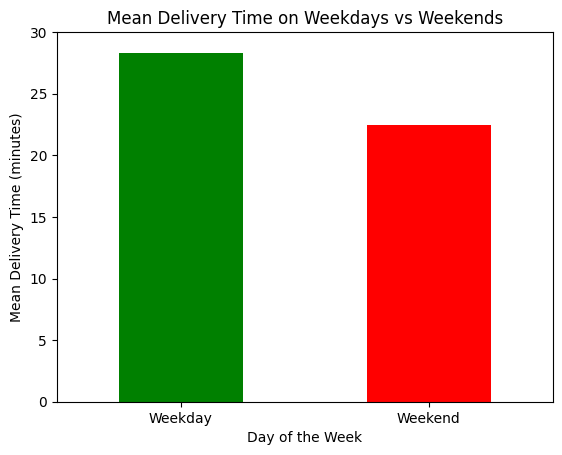

```python
# Grouping the data by weekdays and weekends, and calculating the mean delivery time for each group
grouped_data = df.groupby('day_of_the_week')['delivery_time'].mean()

# Visualize the results using a bar plot
grouped_data.plot(kind='bar', color=['green', 'red'])
plt.xlabel('Day of the Week')
plt.ylabel('Mean Delivery Time (minutes)')
plt.title('Mean Delivery Time on Weekdays vs Weekends')
plt.xticks(rotation=0)
plt.ylim(0, 30)
plt.show()
```

#### Observations:

- *The company analyzed the delivery time of orders on weekdays and weekends. The mean delivery time on weekdays is 28.34 minutes, while on weekends it is 22.47 minutes. This indicates that, on average, orders are delivered faster on weekends compared to weekdays*

### Conclusion and Recommendations

### **Question 17:** What are your conclusions from the analysis? What recommendations would you like to share to help improve the business? (You can use cuisine type and feedback ratings to drive your business recommendations.) [6 marks]

### Conclusion:

The Dataset extracted from the food aggregator company FoodHub who offers access to multiple restaurants and it has been analysed to understand the trend of categories which can be beneficial for business. With the help of descriptive analysis and visualisations, some insights have been drawn as below:

Around 70% of cuisine orders indicates higher on weekends than weekdays

American cuisine is often preferred by the customers

There higher frequency of lower cost orders and exhibits some skewness towards lower cost values

On average, orders are delivered faster on weekends compared to weekdays

Data is relatively consistent and does not contain extreme values that could potentially skew the analysis or affect the interpretation of the results

### Recommendations:

The company can consider offering promotional deals or discounts specifically on weekends, as the analysis shows that there is a higher percentage of cuisine orders on weekends. This can help attract more customers and increase sales during weekends.

The average delivery time indicates a reasonable efficiency in the delivery service. However, the company can further focus on optimizing the delivery process to ensure timely and faster deliveries, particularly on weekdays where the average delivery time is slightly higher. This can help enhance customer experience and satisfaction.

The analysis shows a higher frequency of lower cost orders. The company can conduct further analysis on the cost structure, profit margins, and customer preferences to identify opportunities for pricing optimization, cost reduction, and net revenue generation.

Although the dataset exhibits relatively consistent data without significant outliers, it is still important for the company to monitor and identify any potential outliers in the future. Outliers can provide valuable insights or indicate potential issues that require attention, such as unusually long delivery times or extremely high-cost orders.

As we have a high percentage of Not Rated indications, encourage customers to rate their orders by offering incentives or rewards. This can be in the form of discounts on future orders, loyalty points, or exclusive offers. Providing a clear benefit for rating orders can motivate customers to actively provide feedback.

This will also help enhance the overall customer experience, gather valuable feedback, and improve the accuracy of ratings, leading to a more reliable and informative platform for both customers and restaurants.